# Final project - Results from the MTA-LFZE *Active Music Learning* project

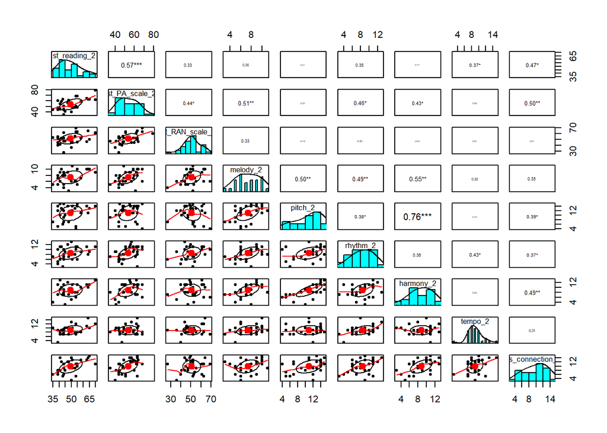

```r
## Posttest associations
# Music class
splom_music_post <- pairs.panels(music_postdata[, c("st_reading_2", "st_PA_scale_2",
                                                    "st_RAN_scale_2", "melody_2",
                                                    "pitch_2", "rhythm_2", "harmony_2",
                                                    "tempo_2", "vis_connection_2")],
                                 scale = TRUE, stars = TRUE, method = "spearman")
```

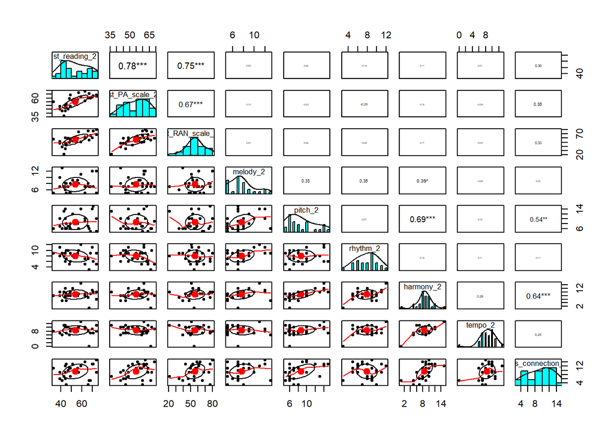

```r
# Maths class
splom_maths_post <- pairs.panels(maths_postdata[, c("st_reading_2", "st_PA_scale_2",
                                                    "st_RAN_scale_2", "melody_2",
                                                    "pitch_2", "rhythm_2", "harmony_2",
                                                    "tempo_2", "vis_connection_2")],
                                 scale = TRUE, stars = TRUE, method = "spearman")
```

```r
# Pretest correlations
pre_music <- as.matrix(corr_music_pre$P)
pre_maths <- as.matrix(corr_maths_pre$P)
# adjusting p-values for multiple comparisons
corr_music_pre$P <- p.adjust(corr_music_pre$P,
                             method = "bonferroni")
corr_maths_pre$P <- p.adjust(corr_maths_pre$P,
                             method = "bonferroni")

# Posttest correlations
post_music <- as.matrix(corr_music_post$P)
post_maths <- as.matrix(corr_maths_post$P)
# adjusting p-values for multiple comparisons
corr_music_post$P <- p.adjust(corr_music_post$P,
                              method = "bonferroni")
corr_maths_post$P <- p.adjust(corr_maths_post$P,
                              method = "bonferroni")
```

### Conclusion

The results of this study did not confirm all of our previous hypotheses. We found differences between the classes only in Block design, Vocabulary and Pitch discrimination performance. Students improved significantly only in Block design, language-related abilitites, melody perception, pitch discrimination, and visual connection. Correlation analyses revealed no overall association between performance on IQ subtests, musical measurements and language-related tests. Moreover, we found significant associations between linguistic and musical auditory abilities only in the music class. These results indicate that improvements in musical and linguistic abilities may appear in the first school year regardless of the intensity of musical activities in elementary school education. Moreover, six months of music education may enhance the strength of relationship between music perception and linguistic abilities.  
Further detailed analyses are required to clarify whether the lack of difference in abilities between the classes and the relationships found between musical auditory skills and language-related abilities in the music class show reliable effects.

### References

Asztalos, K., & Csapó, B. (2016). Development of musical abilities: Cross-sectional computer-based assessments in educational contexts. *Psychology of Music*, 1?17.  
Nagyné Réz, I., Lányiné Engelmayer, Á., Kuncz, E., Mészáros, A., & Mlinkó, R. (2008). *Wechsler Intelligence Scale for Children - fourth edition. Magyar adaptáció [Hungarian adaptation]*. Budapest, HU: OS-Hungary Ltd.  
Tóth, D., Csépe, V., Vaessen, A., & Blomert, L. (2014). *A diszlexia differenciáldiagnózisa. Az olvasás és helyesírás kognitív elemzése. Technikai kézikönyv. [3DM-H: Dyslexia Differential Diagnosis. Cognitive analysis of reading and spelling (Hungarian)]*. Kogentum: Nyíregyháza, Hungary.

#### Acknowledgement

The study was funded by the Content Pedagogy Research Program of the Hungarian Academy of Sciences. For detailed information, see also [http://kodaly.hu/hu/kutatas/aktiv-zenetanulas].